# Waking Up the Golden Dawn

Does Exposure to the Refugees Increase Support for Extreme-Right Parties?

Abstract

The 2015 refugee crisis was the largest displacement of people in Europe since the Second World War, but its political consequences remain contested. This study examines how sudden exposure to refugee arrivals shaped political outcomes in Greece, focusing on Golden Dawn, the country’s extreme-right party. Geography created a stark contrast: some Aegean islands received thousands of arrivals in the summer of 2015, while others nearby were spared. Using a case-oriented, comparative approach combined with process tracing, I show how even fleeting exposure—without sustained contact or resource competition—was translated into heightened support for Golden Dawn. The analysis highlights the symbolic and affective dimensions of crisis politics: brief moments of visibility can trigger narratives of threat and disorder, reconfiguring electoral behavior almost overnight. By treating the refugee crisis as a critical juncture, the study contributes to debates on migration, the extreme right, and democratic resilience, illustrating the “flash potential” of humanitarian shocks to reshape politics in frontline states.

This document is designed as a didactic model for how to structure and write a qualitative research paper using Quarto, LaTeX, and JabRef. It demonstrates best practices in formulating a research question, situating the case within broader debates, building theory, and tracing causal mechanisms with within-case evidence. The Greek refugee crisis of 2015 serves as the illustrative case, showing how geography created natural contrasts across municipalities. For reasons of brevity, the paper reproduces only a subset of the original evidence, serving primarily as a teaching and training resource. The full quantitative study and its results are available in the published article:

Dinas E, Matakos K, Xefteris D, Hangartner D. Waking Up the Golden Dawn: Does Exposure to the Refugee Crisis Increase Support for Extreme-Right Parties? Political Analysis. 2019;27(2):244-254. doi:10.1017/pan.2018.48

# 1 Introduction

## Context

The refugee crisis of 2015 marked the largest displacement of people in Europe since the aftermath of World War II. Millions of asylum seekers—primarily Syrians—crossed the Mediterranean, placing frontline states like Greece under sudden humanitarian and political strain (UNHCR 2017). For Greek society, and particularly for the islands of the Aegean, this influx was not an abstract policy challenge but a lived local reality. Boats arrived without warning, sometimes carrying hundreds of people a day, and island communities became the first point of reception.

These events generated not only pressing logistical and humanitarian dilemmas but also contentious political debates. Across Europe, the crisis intensified disputes over national identity, sovereignty, and borders (Foged and Peri 2016). In Greece, it coincided with a moment of deep economic uncertainty and social unrest, conditions ripe for political entrepreneurs to frame refugee arrivals in ways that resonated with nationalist sentiment. Extreme-right actors such as Golden Dawn seized on these moments, linking the presence of refugees to broader narratives of disorder, cultural threat, and state weakness.

## Research Question

This article investigates whether sudden exposure to the refugee crisis shaped support for Golden Dawn in Greece. Specifically, it asks: *Did municipalities that directly experienced refugee arrivals in 2015 display different electoral dynamics than those that did not?*

The question is not only whether vote shares increased, but how a short-lived humanitarian emergency was translated into durable changes in political behavior.

## Importance

Answering this question matters both empirically and theoretically. A large literature demonstrates that labor migration often fuels anti-immigrant parties (Barone et al. 2016; Mendez and Cutillas 2014; Halla, Wagner, and Zweimüller 2015; Brunner and Kuhn 2014; Becker and Fetzer 2016), but far less is known about refugees. Refugees differ from labor migrants in their motives and in the humanitarian concerns they evoke (Bansak, Hainmueller, and Hangartner 2016). Recent studies in Austria and Denmark reach mixed conclusions (Steinmayr 2016; Dustmann, Vasiljeva, and Damm 2016), leaving open important questions—especially for frontline states like Greece, which received more than half of all arrivals in 2015 (UNHCR 2016).

## Methods and Data: A Case-Oriented Approach

Following the logic of comparative historical analysis (Mahoney 2004; Thelen 1999), this study treats the Aegean islands as a crucial case for understanding how shocks can reorder political alignments. Geography produced a natural divide: some islands faced sudden, massive refugee inflows, while nearby islands with similar characteristics did not. The map in Figure 1 illustrates this contrast, highlighting the municipalities where refugees arrived in large numbers versus those that remained unaffected. This spatial distribution forms the foundation of the case comparison.

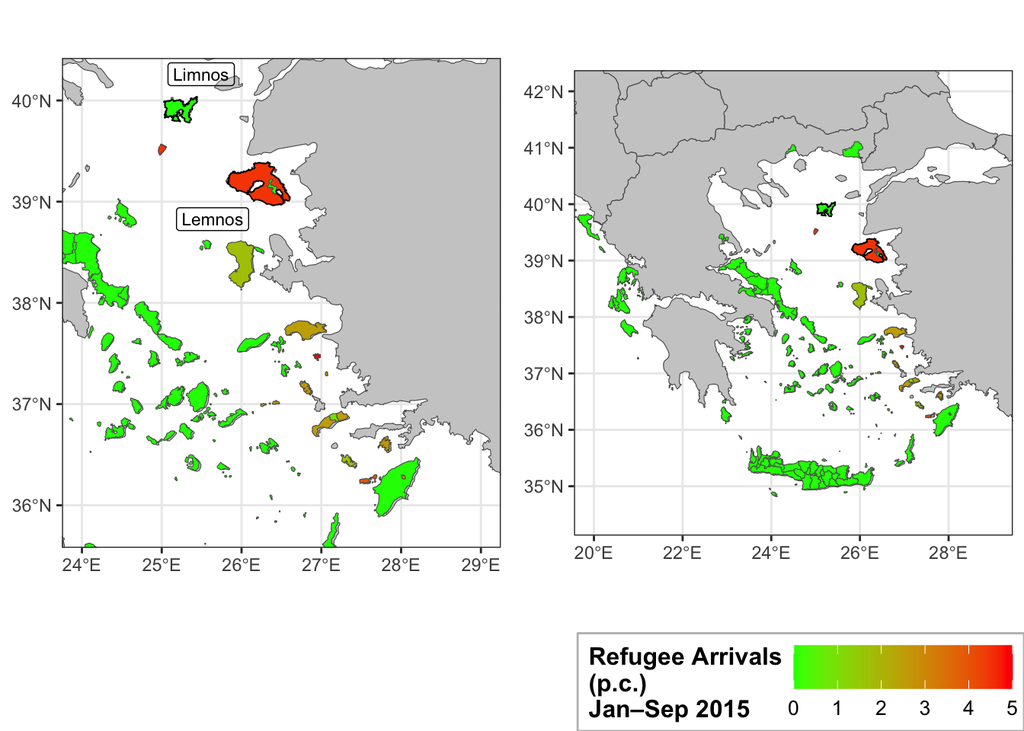

Figure 1: Geographic Distribution of Regugee Arrivals

```r
# ------------------------------------------------------------
# Goal: Read election + map data for Greece, aggregate to the
# municipality-year level, compute vote shares/turnout,
# merge with geographies, and plot refugee arrivals per capita.
# This version adds step-by-step comments for R beginners.
# ------------------------------------------------------------

# --- 0) Housekeeping ---------------------------------------------------------
# Remove all objects from memory so the script starts fresh.
rm(list = ls())

# --- 1) Load packages --------------------------------------------------------
# "haven" reads .dta (Stata) files. "dplyr" is for data wrangling.
# "sf" handles spatial (map) data. "ggplot2" makes plots.
# "here" helps build file paths that work on any computer.
# "ggpubr" arranges multiple ggplots in a grid.
library(haven)
library(dplyr)
library(sf)
sf::sf_use_s2(FALSE)  # turn off spherical geometry to avoid certain topology errors
library(ggplot2)
library(here)
library(ggpubr)

# --- 2) Read data from the /data_final folder -------------------------------
# NOTE: `here("data_final", "file.ext")` builds a path like
# "<your-project-root>/data_final/file.ext". Make sure your working
# directory is the project root (where your .Rproj lives).
countries          <- read_sf(here("data_final", "countries.shp"))
gr_muni            <- read_sf(here("data_final", "gr_muni.shp"))
gr_lemnos_island   <- read_sf(here("data_final", "gr_lemnos_island.shp"))
gr_limnos_island   <- read_sf(here("data_final", "gr_limnos_island.shp"))
all_data           <- read_dta(here("data_final", "dinas_data.dta"), encoding = "UTF-8")

# TIP: If you get errors here, check that files exist and that all
# shapefiles share the same CRS (coordinate reference system).
# Use st_crs(object) to inspect and st_transform(...) to convert if needed.

# --- 3) Sort + group + compute totals at municipality-year level ------------
# We first sort the raw data (not strictly necessary, but helpful to read),
# then group by municipality & year so sums are within each municipality-year.
# The column names below (e.g., `valid`, `gd`, `nd`, etc.) must exist in your data.
all_data <- all_data %>%
  arrange(township, municipality, perfecture, year) %>%   # keep original order logic
  group_by(municipality, year) %>%                        # group for within-muni-year sums
  mutate(
    sumall    = sum(valid,      na.rm = TRUE),  # total valid votes
    sumgd     = sum(gd,         na.rm = TRUE),  # Golden Dawn votes (example)
    sumnd     = sum(nd,         na.rm = TRUE),  # New Democracy votes (example)
    sumsyriza = sum(syriza,     na.rm = TRUE),
    sumpsk    = sum(pasok,      na.rm = TRUE),  # PASOK
    sumkke    = sum(kke,        na.rm = TRUE),
    sumanel   = sum(anel,       na.rm = TRUE),
    sumreg    = sum(registered, na.rm = TRUE)   # number registered to vote
  )

# --- 4) Create vote shares + turnout ----------------------------------------
# Shares = party_total / all valid votes. Turnout = valid / registered.
# Watch for division by zero; NA/NaN can occur if `sumall` or `sumreg` is 0.
all_data <- all_data %>%
  mutate(
    gdvote      = sumgd     / sumall,
    ndvote      = sumnd     / sumall,
    syrizavote  = sumsyriza / sumall,
    pasokvote   = sumpsk    / sumall,
    kkevote     = sumkke    / sumall,
    anelvote    = sumanel   / sumall,
    turnout     = sumall    / sumreg
  )

# --- 5) Keep a single row per municipality-year -----------------------------
# The raw file may have multiple rows per municipality-year (e.g., by township).
# We create a within-group row number and keep the first one (any will do
# once we've already computed muni-year sums above).
datamuni <- all_data %>%
  group_by(geo_muni_id, year) %>%  # use the stable geocode id for join later
  mutate(id = dplyr::row_number()) %>%
  filter(id == 1) %>%              # keep one row per geo_muni_id-year
  arrange(geo_muni_id, year) %>%
  group_by(geo_muni_id) %>%
  mutate(id2 = dplyr::row_number())  # a running index within each municipality

# --- 6) Focus on the 2016 election ------------------------------------------
datamuni_2016 <- subset(datamuni, year == 2016)

# --- 7) Merge tabular data to the municipality shapes ------------------------
# left_join keeps all geometries from gr_muni and adds the 2016 data columns.
# Keys: `ge_mn_d` in the shapefile == `geo_muni_id` in the data.
greece_merge <- left_join(gr_muni, datamuni_2016, by = c("ge_mn_d" = "geo_muni_id"))

# --- 8) Handle missing + extreme values in arrivals per capita --------------
# Remove rows where `trarrprop` (arrivals per capita) is missing so the map
# has valid values to color. Then cap extreme values to improve readability.
greece_merge <- subset(greece_merge, !is.na(trarrprop))

# Make a working copy for plotting + truncation
greece_merge2 <- greece_merge

# One municipality has a very large value (> 100). Following the paper:
# "We truncate the variable at 5 arrivals per capita (i.e., 5 refugees per
# resident), which corresponds to the 99.7th percentile of the non‑zero distribution."
# Doing this avoids a legend dominated by outliers.
greece_merge2$trarrprop[greece_merge2$trarrprop > 100] <- 5

# --- 9) Build two maps (zoomed-in Aegean and full Greece) -------------------
# NOTE: `geom_sf()` draws map layers. The `fill` aesthetic colors municipalities
# by `trarrprop`. The color scale runs from green (low) to red (high).

# (a) Zoomed map around 24–29 E longitude, 35.8–40.2 N latitude
fig1a1 <- ggplot() +
  geom_sf(data = countries, fill = "grey80") +
  geom_sf(data = greece_merge2, aes(fill = trarrprop)) +
  scale_fill_gradient(
    low = "green", high = "red", na.value = "white",
    name = "Refugee Arrivals\n(p.c.)\nJan–Sep 2015"
  ) +
  # Draw and label Lemnos/Limnos to match the original figure
  geom_sf(data = gr_lemnos_island,  color = "black", fill = NA, linewidth = 0.3) +
  geom_sf(data = gr_limnos_island,  color = "black", fill = NA, linewidth = 0.3) +
  geom_sf_label(data = gr_limnos_island, aes(label = name),
                size = 3, nudge_x = 0.35, nudge_y = 0.35, alpha = 0.2) +
  geom_sf_label(data = gr_lemnos_island, aes(label = name),
                size = 3, nudge_x = -0.35, nudge_y = -0.35, alpha = 0.2) +
  coord_sf(xlim = c(24, 29), ylim = c(35.8, 40.2)) +
  theme_bw() +
  theme(
    legend.title        = element_text(size = 12, face = "bold"),
    legend.text         = element_text(size = 10),
    legend.key          = element_rect(fill = "yellow", color = "grey", size = 1),
    legend.key.size     = unit(1.5, "lines"),
    legend.background   = element_rect(fill = "white", color = "grey"),
    legend.box.background = element_rect(color = "grey"),
    # Position legend inside the plotting area at the top-right corner
    legend.position     = c(1, 1),
    legend.justification = c("right", "top"),
    axis.title.x        = element_blank(),
    axis.title.y        = element_blank()
  )

# (b) Wider map of Greece
fig1a2 <- ggplot() +
  geom_sf(data = countries, fill = "grey80") +
  geom_sf(data = greece_merge2, aes(fill = trarrprop)) +
  scale_fill_gradient(
    low = "green", high = "red", na.value = "white",
    name = "Refugee Arrivals\n(p.c.)\nJan–Sep 2015"
  ) +
  geom_sf(data = gr_lemnos_island, color = "black", fill = NA, linewidth = 0.3) +
  geom_sf(data = gr_limnos_island, color = "black", fill = NA, linewidth = 0.3) +
  # Labels are optional here; commented out to reduce clutter
  # geom_sf_label(data = gr_limnos_island, aes(label = name),  size = 3, nudge_x = 0.35, nudge_y = 0.35, alpha = 0.2) +
  # geom_sf_label(data = gr_lemnos_island, aes(label = name),  size = 3, nudge_x = -0.35, nudge_y = -0.35, alpha = 0.2) +
  coord_sf(xlim = c(20, 29), ylim = c(34.5, 42)) +
  theme_bw() +
  theme(
    legend.title        = element_text(size = 12, face = "bold"),
    legend.text         = element_text(size = 10),
    legend.key          = element_rect(fill = "yellow", color = "grey", size = 1),
    legend.key.size     = unit(1.5, "lines"),
    legend.background   = element_rect(fill = "white", color = "grey"),
    legend.box.background = element_rect(color = "grey"),
    legend.position     = c(1, 1),
    legend.justification = c("right", "top"),
    axis.title.x        = element_blank(),
    axis.title.y        = element_blank()
  )

# --- 10) Arrange the two plots side-by-side ----------------------------------
# `ggarrange()` puts multiple ggplots in a single figure.
# `common.legend = TRUE` puts one shared legend at the bottom.
row1 <- ggarrange(fig1a1, fig1a2, ncol = 2, common.legend = TRUE, legend = "bottom")

# --- 11) Optional: save to file ---------------------------------------------
# ggsave(here("figures", "refugee_arrivals_maps.png"), row1, width = 10, height = 6, dpi = 300)

# Print to the RStudio plotting pane (or your device if using ggsave later)
print(row1)
```

## Methods and Data: Process Tracing and Mechanisms

The analysis is guided by process-tracing logic (Bennett and Checkel 2015). Rather than assuming exposure mechanically produces vote shifts, it asks how actors and narratives translated a humanitarian shock into political outcomes. Three steps are central to the hypothesized mechanism:

1. Shock of Arrival – Refugees landed on local shores in highly visible numbers, creating a sense of sudden disruption.
2. Interpretive Framing – Media coverage and Golden Dawn’s rhetoric cast arrivals as threats to order and identity.
3. Electoral Response – Voters in exposed municipalities shifted toward Golden Dawn as the party most clearly articulating a hardline stance.

This sequence directs attention to the microfoundations of political change, situating quantitative evidence within a broader causal narrative.

## Findings and Contribution

The findings show that municipalities exposed to refugee arrivals saw a marked rise in Golden Dawn’s vote share, even though refugees rarely remained in these communities for long. This supports an interpretation in which exposure activated narratives of threat and identity politics, amplifying support for extreme-right actors.

More broadly, the case contributes to debates on how crises reshape politics. Thelen and Pierson emphasize that shocks and critical junctures often reconfigure existing trajectories (Pierson 2004; Thelen 2004). The Greek case demonstrates how short-lived humanitarian emergencies can generate enduring political effects—not through sustained contact or material competition, as predicted by contact theory (Allport 1979) or realistic group conflict theory (Campbell 1965), but through symbolic politics and the framing of threat. In this way, it illustrates the “flash potential” of refugee crises (Hopkins 2010), where brief moments of visibility produce disproportionate political consequences.

## Structure of the Paper

The following sections situate the Greek case in the broader European context, outline the case-selection strategy and data sources, trace the causal process linking refugee arrivals to local political dynamics, and present supporting evidence, including both descriptive comparisons and quantitative tests. The final section discusses the theoretical implications for the study of crisis, migration, and the extreme right.

# 2 Literature Review

## Introduction to the Debate

The relationship between migration and support for extreme-right parties has been widely studied, but the findings differ depending on whether the focus is on labor migration or refugee migration. While much of the literature documents a positive association between immigration and support for far-right parties, fewer studies isolate the specific effects of refugee inflows. This distinction matters because refugees are perceived differently from labor migrants: their arrival is often framed in humanitarian rather than economic terms (Bansak, Hainmueller, and Hangartner 2016).

## Labor Migration and Electoral Backlash

A large body of research links labor migration to electoral gains for anti-immigrant parties. Studies across Spain, Austria, Germany, and Switzerland find that increases in immigration correlate with stronger support for the far-right (Barone et al. 2016; Mendez and Cutillas 2014; Halla, Wagner, and Zweimüller 2015; Brunner and Kuhn 2014; Becker and Fetzer 2016). These works often emphasize competition over jobs, housing, and welfare resources, consistent with realistic group conflict theory (Campbell 1965). The underlying claim is that immigration intensifies competition, leading natives to support exclusionary parties.

## Refugees as a Distinct Category

Refugee inflows differ from labor migration in both scale and framing. Humanitarian concerns can make host populations more sympathetic (Bansak, Hainmueller, and Hangartner 2016), potentially moderating backlash. Recent work has directly examined refugees’ political effects, though findings remain mixed. For Austria, exposure to refugees reduced support for the far-right, consistent with contact theory, which argues that sustained interaction with out-groups reduces prejudice (Steinmayr 2016; Allport 1979). By contrast, in Denmark, exposure to refugees increased hostility and electoral support for the far-right (Dustmann, Vasiljeva, and Damm 2016). These contradictory results suggest that context and mechanisms of exposure matter: whether refugees are seen as temporary transients or potential long-term residents, and whether natives have opportunities for meaningful interaction.

## The Greek Case and Existing Gaps

Despite its centrality to the refugee crisis, Greece has received little systematic study. In 2015, more than half of all asylum seekers entering Europe passed through Greek islands (UNHCR 2016). Yet the political consequences of this unprecedented inflow remain underexplored. The existing literature leaves two critical gaps.

1. **Case Gap**: Greece, one of the most affected countries, has not been studied in depth, even though it is home to Golden Dawn, the most extreme-right party represented in a European parliament at the time (Heinö 2016).
2. **Mechanism Gap**: Prior work often conflates exposure and contact. Yet in contexts where refugees are only briefly present—such as the Aegean islands, where most continued to the mainland within 48 hours (Capon 2015)—contact theory cannot apply. This makes it possible to isolate the effect of exposure alone, independent of sustained interaction or direct competition for resources.

## Contribution

This paper addresses these gaps by studying Greece during the 2015 refugee crisis. It introduces new evidence from the Aegean islands, where geography meant that some islands received thousands of arrivals while others nearby did not. This situation creates a kind of natural comparison, allowing us to see how sudden exposure shaped political outcomes.

The contribution is threefold. First, it shows that mere exposure—even without long-term contact or competition for resources—can increase far-right vote share. Second, it helps explain why earlier studies disagree: the key difference is whether refugees were temporary passersby or longer-term residents. Third, it expands the comparative scope by analyzing Greece, a frontline country and home to Golden Dawn, the most extreme-right party in a European parliament at the time. This makes Greece a critical test case for what scholars call the “flash potential” of refugee crises—the idea that brief but visible moments of crisis can reshape politics (Sniderman, Hagendoorn, and Prior 2004; Hopkins 2010).

# 3 Theory and Argument

## Key Concepts

The outcome of interest is electoral support for Golden Dawn (GD), Greece’s extreme-right party that fused ultranationalist rhetoric with xenophobic appeals (Heinö 2016). The key explanatory factor is *exposure to refugees*, understood as the sudden, localized presence of asylum seekers on Greek islands during the 2015 crisis. Importantly, “exposure” here refers not to long-term integration but to highly visible, short-term encounters that disrupted local routines and political discourse.

## Theoretical Framework

Two classic perspectives—contact theory and realistic group conflict theory—offer limited leverage in this case.

- Contact theory suggests that sustained interaction reduces prejudice (Allport 1979), but refugees transited through Greek islands too briefly to permit such exchanges.
- Realistic group conflict theory emphasizes competition over resources (Campbell 1965), yet the fleeting presence of refugees on islands precluded meaningful economic rivalry.

Instead, this study builds on insights from historical institutionalism and process tracing (Mahoney 2004; Thelen 1999; Bennett and Checkel 2015). It treats the refugee crisis as a critical juncture, in which a sudden shock disrupted local equilibria and created opportunities for political entrepreneurs. Golden Dawn mobilized this moment by framing arrivals as a threat to order and identity. The process is thus interpretive and symbolic, not material.

## Argument

The core claim is that *exposure alone*, even without contact or competition, can activate latent predispositions. Sudden visibility of large numbers of refugees generated a sense of disruption. Through rhetorical framing by elites and media, this shock was translated into heightened perceptions of threat. These perceptions, in turn, increased support for Golden Dawn.

This argument highlights mechanisms rather than laws:

1. **Shock of Arrival** → visibility of mass inflows disrupted routines.
2. **Framing and Interpretation** → nationalist actors cast arrivals as threats.
3. **Electoral Response** → voters turned to Golden Dawn as the most credible vehicle for these concerns.

## Causal Framework (DAG)

The logic can be visualized in a heuristic diagram:

- **Explanatory Factor**: Refugee Arrivals (driven by proximity to Turkey)
- **Mechanism**: Perceptions of Threat (cultural, symbolic, security)
- **Outcome**: Golden Dawn Vote Share

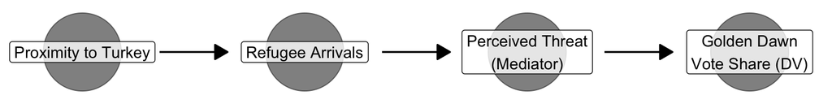

Figure 2: Causal Framework (DAG)

```r
# ------------------------------------------------------------
# Goal: Draw a simple Directed Acyclic Graph (DAG) that represents
# a theory of how exposure to refugees affects Golden Dawn (GD) vote share.
# This DAG uses ggdag + dagitty + ggplot2.
#
# Key idea: We draw *nodes* (circles) for variables and *arrows* for
#           hypothesized causal effects. We'll also show how to make
#           arrows shorter so they don't touch the nodes.
# ------------------------------------------------------------

# --- 0) Playground: tweak these safely -------------------------------
node_size    <- 25    # how big each node (circle) is
node_alpha   <- 0.5   # transparency of node fill (0 = invisible, 1 = solid)
arrowhead_pt <- 10    # arrowhead size in points (this is the *tip* triangle)
trim         <- 0.20  # how much of the arrow *shaft* to chop off from BOTH ends
                     # e.g., 0.20 = remove 20% at the start AND 20% at the end
                     # so the arrow in the middle is 60% of the original length

# --- 1) Load required packages ----------------------------------------------
# ggdag   → helper functions to draw DAGs in ggplot2
# dagitty → defines DAG objects and relationships between variables
# ggplot2 → plotting system used to visualize the DAG
library(ggdag)
library(dagitty)
library(ggplot2)

# --- 2) Define the DAG structure --------------------------------------------
# dagify() creates a DAG object where you specify arrows (causal paths).
# The notation A ~ B means "A is caused by B".
# Here:
#   GDvote   ← threat     (Golden Dawn vote share caused by perceived threat)
#   threat   ← exposure   (Threat is caused by exposure to refugees)
#   exposure ← distance   (Exposure caused by proximity to Turkey)
# Labels: provide readable names for the DAG nodes (with line breaks).
# Coords: x and y positions of each node (for nice plotting layout).
theory_dag <- dagify(
  GDvote ~ threat,             # DV (Golden Dawn vote share) depends on threat
  threat ~ exposure,           # Threat depends on exposure
  exposure ~ distance,         # Exposure depends on distance
  labels = c(
    GDvote   = "Golden Dawn\nVote Share (DV)",
    threat   = "Perceived Threat\n(Mediator)",
    exposure = "Refugee Arrivals",
    distance = "Proximity to Turkey"
  ),
  coords = list(
    x = c(distance = 0, exposure = 1, threat = 2, GDvote = 3),
    y = c(distance = 1, exposure = 1, threat = 1, GDvote = 1)
  )
)

# --- 3) Convert DAG into a data frame for ggplot ----------------------------
# tidy_dagitty() extracts coordinates, labels, and edges for plotting.
# as.data.frame() makes it into a tibble/data frame usable by ggplot.
dag_df <- as.data.frame(tidy_dagitty(theory_dag, layout = "auto"))

# Extract plotting limits (so the nodes don’t touch the plot borders).
min_x <- min(dag_df$x); max_x <- max(dag_df$x)
min_y <- min(dag_df$y); max_y <- max(dag_df$y)
error <- 0.2  # small padding around the plot

# --- 3.5) Make arrow *segments* shorter and floating between nodes ----------
# Important: In ggplot, the "arrow()" only controls the arrowhead (the little
# triangle tip). It does NOT control the length of the shaft. Shaft length is
# determined by the start (x, y) and end (xend, yend) coordinates.
#
# To make arrow shafts shorter AND not start at the node centers, we:
# 1) Find all edge rows (they have xend/yend values).
# 2) Move the start point forward by 'trim' proportion along the edge.
# 3) Move the end point backward by 'trim' proportion along the edge.
# The result: the arrow appears between nodes without touching them.
edges_df <- subset(dag_df, !is.na(xend) & !is.na(yend))

# Safety checks: ensure trim is between 0 and 0.49
# (If trim >= 0.5 the start could pass the end!)
trim <- max(min(trim, 0.49), 0.00)

# Compute trimmed start (xstart_trim, ystart_trim) and end (xend_trim, yend_trim)
edges_df$xstart_trim <- edges_df$x   + trim * (edges_df$xend - edges_df$x)
edges_df$ystart_trim <- edges_df$y   + trim * (edges_df$yend - edges_df$y)
edges_df$xend_trim   <- edges_df$xend - trim * (edges_df$xend - edges_df$x)
edges_df$yend_trim   <- edges_df$yend - trim * (edges_df$yend - edges_df$y)

# --- 4) Plot the DAG --------------------------------------------------------
# Each node is a big semi-transparent point with a label on top.
# Edges (arrows) are drawn with geom_dag_edges_arc using the *trimmed* endpoints.
ggplot(data = dag_df) +
  # Draw big transparent points for each node
  geom_dag_point(aes(x = x, y = y), size = node_size, alpha = node_alpha) +

  # Add text labels (only once per node → !duplicated(label))
  geom_label(
    data = subset(dag_df, !duplicated(label)),
    aes(x = x, y = y, label = label),
    fill = alpha("white", 0.8)
  ) +

  # Draw arrows between nodes (edges of the DAG)
  # NOTE: arrow(length = ...) controls ONLY the arrowhead size (the tip).
  # The shaft length is controlled by the start/end coordinates we just trimmed.
  geom_dag_edges_arc(
    data = edges_df,
    aes(x = xstart_trim, y = ystart_trim, xend = xend_trim, yend = yend_trim),
    curvature = 0.0,
    arrow = grid::arrow(length = grid::unit(arrowhead_pt, "pt"), type = "closed")
  ) +

  # Set x- and y-limits to keep everything inside the plot
  coord_sf(
    xlim = c(min_x - error, max_x + error),
    ylim = c(min_y - error, max_y + error)
  ) +

  # Minimal background → removes axes, gridlines, etc.
  theme_void()
```

## Hypotheses

- **H1 (Exposure Proposition)**: Municipalities suddenly exposed to refugee arrivals will be more likely to shift toward Golden Dawn than otherwise similar municipalities.
- **H2 (Intensity Proposition)**: Greater per-capita exposure heightens this effect, as larger shocks amplify the salience of threat frames.

These are not statistical hypotheses but **process expectations** to be evaluated through within-case evidence and comparisons across municipalities.

## Scope Conditions

The argument applies under specific conditions:

- **Temporal scope**: Sudden refugee crises that produce short-lived but visible shocks.
- **Spatial scope**: Frontline regions where geography funnels inflows unevenly across localities.
- **Political scope**: Contexts with radical-right actors positioned to mobilize around narratives of identity and insecurity.

# 4 Methods

## Research Design

This study uses a **qualitative, case-oriented research design** to investigate how sudden refugee arrivals shaped electoral support for Golden Dawn (GD). The Greek islands offer a natural comparison: geography exposed some municipalities to large inflows of asylum seekers in 2015, while others nearby, with similar economic and political histories, saw few or none.

Rather than estimating average treatment effects through statistical models, the design follows the logic of process tracing and comparative historical analysis (Mahoney 2004; Bennett and Checkel 2015). It seeks to identify the mechanisms that linked a short-lived humanitarian shock to electoral outcomes. The analysis proceeds in two steps:

1. **Cross-case comparison** – contrasting municipalities exposed to refugee arrivals with those not exposed, focusing on similarities and differences in subsequent electoral trajectories.
2. **Within-case analysis** – tracing the sequence of events in exposed municipalities (shock of arrival → interpretive framing → electoral response), using evidence from election returns, media reports, and party rhetoric.

The unit of analysis is the municipality (N = 95). The temporal scope covers four parliamentary elections between 2012 and 2015, allowing comparison of electoral patterns before and after the refugee crisis.

## Data

Two primary sources are used:

1. **Electoral outcomes**: Official election returns from the Greek Ministry of Interior and Public Administration, at a municipality level, for all four elections.
2. **Refugee arrivals**: Monthly data from the UNHCR, aggregated to the municipal level and expressed as arrivals per capita. I truncate the measure at five arrivals per resident (the 99.7th percentile of the non-zero distribution) to prevent extreme values from skewing results.

Supplementary evidence comes from media coverage, NGO reports, and party statements, which help reconstruct the framing process by which arrivals were politicized.

## Analytic Strategy

The analysis combines comparative and process-tracing logics:

- **Comparative logic**: By juxtaposing exposed and non-exposed municipalities, the study asks whether refugee arrivals corresponded with divergent political trajectories.
- **Process-tracing logic**: Within exposed municipalities, the study examines how the sudden visibility of refugees was interpreted and politicized. The expectation is that the mechanism unfolded in three steps: (1) visible shock of arrival, (2) framing of threat by elites and media, (3) voter response in the September 2015 election.

# 5 Findings

## Exposure and Divergence in Electoral Support

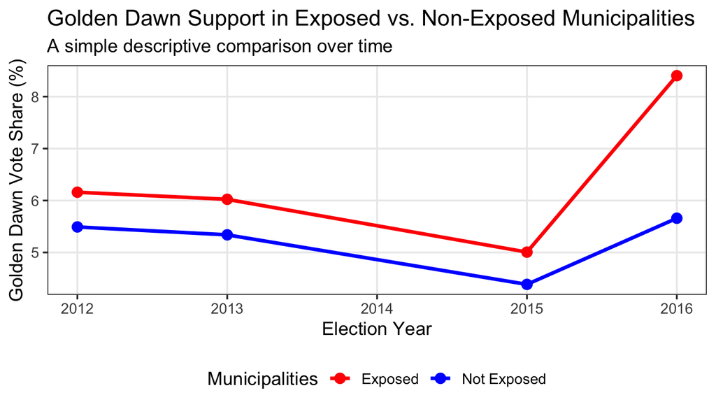

Figure 3: Golden Dawn vote share diverged after refugee arrivals (2015).

```r
# ------------------------------------------------------------
# Goal: Make a simple, readable line chart showing average
# Golden Dawn (GD) vote share over time for Exposed vs Not Exposed
# municipalities. This is a *descriptive* plot, not a test.
# ------------------------------------------------------------

# 0) Load packages ------------------------------------------------------------
# ggplot2  → plotting
# dplyr    → "verbs" for data wrangling (mutate, group_by, summarize)
library(ggplot2)
library(dplyr)


# 2) Create a clean, small summary table for plotting -------------------------
# - gdvote is assumed to be a proportion (0–1), so multiply by 100.
# - "group" becomes a readable label for the legend.
df_muni_avg <- datamuni %>%
  mutate(
    gdper = gdvote * 100,
    group = ifelse(treatment_group == 1, "Exposed", "Not Exposed")
  ) %>%
  group_by(group, year) %>%
  summarize(
    gd_mean = mean(gdper, na.rm = TRUE),  # average GD% for that group×year
    n       = dplyr::n()                 # how many municipalities in this cell
  )



# 3) Make the plot ------------------------------------------------------------
ggplot(df_muni_avg, aes(x = year, y = gd_mean, color = group, group = group)) +
  geom_line(linewidth = 1.2) +   # thicker line for readability
  geom_point(size = 3) +         # add dots so each year is clear
  scale_color_manual(values = c("Exposed" = "red", "Not Exposed" = "blue")) +
  labs(
    x = "Election Year",
    y = "Golden Dawn Vote Share (%)",
    color = "Municipalities",
    title = "Golden Dawn Support in Exposed vs. Non-Exposed Municipalities",
    subtitle = "A simple descriptive comparison over time"
  ) +
  # theme_bw = clean base theme; base_size nudges fonts larger for slides
  theme_bw(base_size = 13) +
  # Small style tweaks: move legend to bottom, lighten gridlines
  theme(
    legend.position = "bottom",
    panel.grid.minor = element_blank()
  )
```

## Mechanisms: Symbolic Shock and Threat Perception

Process-tracing of media reports, local accounts, and party rhetoric reveals how exposure without contact still reshaped perceptions. Refugees typically stayed on islands for less than 48 hours (Capon 2015), making sustained interaction impossible. Instead, their arrival produced a symbolic shock:

- Local newspapers carried front-page images of crowded shorelines and overwhelmed ports.
- Golden Dawn leaders framed the arrivals as an “invasion,” emphasizing loss of sovereignty and cultural threat.
- Municipal authorities described sudden strain on services, even when material competition was minimal.

These narratives resonated with voters predisposed to nationalist appeals. The timing—arrivals in summer 2015 followed by elections in September—suggests a rapid link between the symbolic framing of crisis and electoral support for GD.

This finding helps explain why Greece diverges from Steinmayr’s (Steinmayr 2016) Austrian case, where sustained interaction softened hostility, and instead resembles Dustmann et al.’s (Dustmann, Vasiljeva, and Damm 2016) Danish findings of heightened backlash. In short, when exposure is fleeting but visible, the threat narrative dominates over contact effects.

## Variation by Intensity and Proximity

Not all exposed municipalities reacted equally. Islands that received larger per-capita inflows (e.g., Lesvos, Chios) saw the sharpest jumps in GD support. By contrast, islands with limited arrivals showed smaller changes. Proximity to Turkey reinforced this dynamic: the closer an island, the more visible and concentrated the inflows, and the stronger the electoral reaction.

Taken together, these findings highlight the graded nature of symbolic exposure of symbolic exposure: greater intensity amplified perceptions of crisis, while distance muted them.

## Summary of Findings

These results directly answer the research question: **Did exposure to refugees increase support for Golden Dawn?** The answer is yes. Brief exposure, even without direct competition or meaningful contact, increased far-right support by activating symbolic threat perceptions.

- **Thematically**, the findings show (1) a divergence in electoral trajectories, (2) mechanisms rooted in symbolic shock, and (3) variation by intensity/proximity.
- **Comparatively**, Greece contributes a crucial case to the broader literature: unlike Austria, but like Denmark, it demonstrates that context and mechanism of exposure determine political outcomes.
- **Conceptually**, this underscores the “flash potential” of refugee crises (Sniderman, Hagendoorn, and Prior 2004; Hopkins 2010): short, visible shocks can realign politics in ways disproportionate to their material impact.

# 6 Discussion

## Contribution

This study demonstrates that even brief and localized exposure to refugees can reshape political dynamics, increasing support for Golden Dawn, Greece’s extreme-right party. In doing so, it challenges the prevailing emphasis in the literature on long-term labor migration and resource competition (Barone et al. 2016; Halla, Wagner, and Zweimüller 2015; Becker and Fetzer 2016). The Greek case shows that exposure alone—without sustained interaction or direct economic rivalry—can have significant political consequences.

By tracing how short-lived encounters produced a surge in extremist support, this article contributes to debates about the “flash potential” of refugee crises (Sniderman, Hagendoorn, and Prior 2004; Hopkins 2010). It reframes refugee inflows not as gradual extensions of immigration dynamics, but as sudden political shocks that can reorder electoral behavior almost instantaneously.

## Broader Implications

The findings underscore the symbolic and affective dimensions of immigration politics. Refugees’ passage through the Aegean islands—often lasting less than 48 hours—was sufficient to generate perceptions of crisis and insecurity. This suggests that narratives of disorder, cultural threat, and national sovereignty can be as politically powerful as material concerns.

The case complicates existing theories of contact (Allport 1979) and conflict (Campbell 1965), which assume sustained interaction or competition. Instead, it highlights the role of exposure without contact, where fleeting but visible encounters trigger political backlash. For scholars, this implies the need to conceptualize refugee movements not only as demographic pressures, but also as moments of symbolic politics. For policymakers, it suggests that the framing and visibility of refugee arrivals can be just as consequential as the material realities of settlement.

## Limitations and Future Research

Three limitations merit reflection. First, the analysis is confined to the Greek islands in 2015. The dynamics of exposure may differ in mainland settings, or in countries where institutional capacities and party systems vary. Second, while process-tracing of electoral outcomes and political discourse illuminates how exposure shaped perceptions, the precise mechanisms—media amplification, nationalist rhetoric, or local anxieties about control—require further investigation. Third, the focus on electoral outcomes leaves broader civic and attitudinal consequences unexplored.

Future research should extend this analysis in three ways:

1. Cross-national comparisons, to identify how institutional and cultural contexts condition the effect of refugee crises.
2. Survey and interview evidence, to capture how ordinary citizens interpret exposure.
3. Media analysis, to trace how local and national narratives amplify or dampen symbolic shocks.

# 7 Conclusion

## Restating the Argument

This article has shown that localized exposure to the 2015 refugee crisis reshaped political outcomes in Greece. Even when refugees were present only briefly and without direct competition for resources, their arrival coincided with a surge in electoral support for Golden Dawn, the country’s extreme-right party. The Greek case suggests that the symbolic impact of refugee flows, rather than material pressures, can drive rapid political change.

## Contribution to the Literature

The study contributes to debates on migration and political behavior by reframing refugees as a distinct type of political shock. Whereas long-term labor migration is often understood through the lenses of competition or integration, refugee arrivals highlight dynamics of immediacy, visibility, and perceived disorder. This builds on but also complicates findings from Austria and Denmark, showing how frontline states face unique challenges when sudden exposure activates nationalist and exclusionary politics.

## Broader Implications

The findings underscore the fragility of democratic systems in the face of sudden demographic and symbolic disruptions. Refugee crises are not only humanitarian or economic episodes; they also serve as political turning points, amplifying anxieties about identity, security, and state authority. This perspective encourages scholars and policymakers alike to recognize that moments of crisis can catalyze shifts in party competition and public discourse more quickly than gradual structural changes.

## Unresolved Questions

Several questions remain open. What precise mechanisms transformed fleeting encounters with refugees into durable political effects—media framing, nationalist mobilization, or citizens’ perceptions of state weakness? Under what circumstances might such effects fade rather than persist? And how might other frontline or transit states experience similar dynamics? Addressing these questions will require cross-national and multi-method research, combining electoral analysis with surveys, interviews, and media studies.

## Normative Reflection

Finally, the Greek case reminds us that democratic resilience cannot be taken for granted. If momentary shocks can so quickly empower extremist actors, then societies must invest in institutions, narratives, and forms of civic engagement that reduce vulnerability to fear-based mobilization. Refugee crises will not be the last challenge to Europe’s democracies, but how they are framed and politically managed may determine whether they erode pluralism or strengthen it.

# 8 References

Allport, Gordon W. 1979. *The Nature of Prejudice*. Reading, MA: Addison-Wesley Pub. Co.

Bansak, Kirk, Jens Hainmueller, and Dominik Hangartner. 2016. “How Economic, Humanitarian, and Religious Concerns Shape European Attitudes Toward Asylum Seekers.” *Science* 354 (6309): 217–22.

Barone, Guglielmo, Alessio D’Ignazio, Guido de Blasio, and Paolo Naticchioni. 2016. “Mr. Rossi, Mr. Hu and Politics. The Role of Immigration in Shaping Natives’ Voting Behavior.” *Journal of Public Economics* 136: 1–13.

Becker, Sascha O., and Thiemo Fetzer. 2016. “Does Migration Cause Extreme Voting.” 306. CAGE Working Paper.

Bennett, Andrew, and Jeffrey T. Checkel, eds. 2015. *Process Tracing: From Metaphor to Analytic Tool*. Cambridge: Cambridge University Press. https://doi.org/10.1017/CBO9781139858472.

Brunner, Beatrice, and Andreas Kuhn. 2014. “Immigration, Cultural Distance and Natives’ Attitudes Towards Immigrants: Evidence from Swiss Voting Results.” *Kyklos* 71 (1): 28–58.

Campbell, Donald T. 1965. “Ethnocentric and Other Altruistic Motives.” In *Nebraska Symposium on Motivation*, edited by David Levine, 13:283–311. Lincoln, NE: University of Nebraska Press.

Capon, Felicity. 2015. “Greek Island Ferries Fully Booked as Refugees Stream to Mainland.” https://www.newsweek.com/greek-island-ferries-fully-booked-refugees-stream-mainland-364295.

Dustmann, Christian, Kristine Vasiljeva, and Anna Piil Damm. 2016. “Refugee Migration and Electoral Outcomes.” 19/16. CReAM.

Foged, Mette, and Giovanni Peri. 2016. “Immigrants’ Effect on Native Workers: New Analysis on Longitudinal Data.” *American Economic Journal: Applied Economics* 8 (2): 1–34.

Halla, Martin, Alexander F. Wagner, and Josef Zweimüller. 2015. “Immigration and Voting for the Far Right.” *Journal of the European Economic Association* 15 (6): 1341–85.

Heinö, Andreas Johansson. 2016. “Timbro’s Authoritarian Populism Index 2016.” https://timbro.se/allmant/timbro-authoritarian-populism-index-2016/.

Hopkins, Daniel J. 2010. “Politicized Places: Explaining Where and When Immigrants Provoke Local Opposition.” *American Political Science Review* 104 (1): 40–60.

Mahoney, James. 2004. “Comparative-Historical Methodology.” *Annual Review of Sociology* 30: 81–101. https://doi.org/10.1146/annurev.soc.30.012703.110510.

Mendez, Isaac, and Ignacio M. Cutillas. 2014. “Has Immigration Affected Spanish Presidential Elections Results?” *Journal of Population Economics* 27 (1): 135–71.

Pierson, Paul. 2004. *Politics in Time: History, Institutions, and Social Analysis*. Princeton, NJ: Princeton University Press.

Sniderman, Paul M., Louk Hagendoorn, and Markus Prior. 2004. “Predisposing Factors and Situational Triggers: Exclusionary Reactions to Immigrant Minorities.” *American Political Science Review* 98 (1): 35–49.

Steinmayr, Andreas. 2016. “Exposure to Refugees and Voting for the Far-Right: (Unexpected) Results from Austria.” Discussion Paper 9790. IZA.

Thelen, Kathleen. 1999. “Historical Institutionalism in Comparative Politics.” *Annual Review of Political Science* 2 (1): 369–404. https://doi.org/10.1146/annurev.polisci.2.1.369.

———. 2004. *How Institutions Evolve: The Political Economy of Skills in Germany, Britain, the United States and Japan*. Cambridge: Cambridge University Press. https://doi.org/10.1017/CBO9780511790997.

UNHCR. 2016. “Emergency Information Sharing Web Portal.” http://data.unhcr.org/mediterranean/regional.php.

———. 2017. “Mid-Year Trends 2016.” http://www.unhcr.org/en-us/statistics/unhcrstats/58aa8f247/mid-year-trends-june-2016.html.

# 9 Appendix

## Timeline of Refugee Arrivals

The refugee crisis reached its peak in Greece in 2015. Table S1 summarizes the key moments that shaped the flow of arrivals and the political context in which they occurred.

| Date | Event | Political Context (Greece) |
| --- | --- | --- |
| January 2015 | Syriza wins parliamentary elections | Golden Dawn receives 6.3% of the vote |
| Summer 2015 | Surge in arrivals from Turkey to Greek islands (esp. Lesvos, Kos) | Growing public concern |
| September 2015 | Peak refugee arrivals (over 200,000 in a single month) | Snap elections; Golden Dawn receives 7.0% |
| October–December 2015 | EU–Turkey negotiations intensify | Refugee presence framed as crisis management issue |

Table S1: Timeline of Refugee Arrivals

## Election Context

Golden Dawn’s electoral performance can be understood in relation to broader electoral trends. Table S2 provides a summary of national parliamentary elections from 2012 to 2015.

| Election Date | Turnout (%) | Golden Dawn Vote Share (%) | Notes |
| --- | --- | --- | --- |
| May 2012 | 65.1 | 7.0 | GD enters parliament for the first time |
| June 2012 | 62.5 | 6.9 | GD consolidates support |
| January 2015 | 63.9 | 6.3 | Syriza victory |
| September 2015 | 56.6 | 7.0 | Elections held amid refugee crisis |

Table S2: Election Context

## Local Media and Public Discourse

Qualitative sources shed light on how refugees were perceived. Selected headlines from Greek newspapers and television outlets in 2015 illustrate the framing of the crisis:

- *Kathimerini* (August 2015): “Islands Overwhelmed: Refugee Arrivals Triple in One Month”
- *To Vima* (September 2015): “The State Absent, the Islands Alone Against the Crisis”
- Local Lesvos newspaper (*Empros*, September 2015): “Fear and Solidarity: Two Faces of the Refugee Arrivals” These accounts show how refugee arrivals were framed not only as a humanitarian issue but also as a question of state capacity and security, resonating with Golden Dawn’s anti-system appeals.

## Supplementary Notes

1. **Data Sources**: UNHCR (monthly refugee arrivals), Greek Ministry of Interior (electoral results), EU reports, and local press archives.
2. **Unit of Analysis**: Municipalities on Aegean islands, but qualitative evidence also highlights broader discursive shifts at the national level.
3. **Limitations**: While these supplementary materials provide valuable context, they cannot fully disentangle mechanisms such as media influence, nationalist mobilization, or perceptions of state weakness.

# 10 Example AI Transparency Statement

## Use of AI for Writing Support

Artificial intelligence tools were used in a limited capacity to support the clarity and flow of the written text. Specifically, AI was employed to correct grammatical and stylistic issues and to suggest improvements in signposting (e.g., subheadings, transitions between sections). These interventions were strictly editorial. The research design, theoretical argument, and engagement with the literature were developed independently in consultation with the advisor.

## Use of AI for Organizational Support

AI was also used to provide suggestions on structuring the appendix and discussion sections. This support was comparable to feedback that could be obtained from a writing tutor or style manual, focusing on presentation rather than substantive content. No AI tools were used to generate evidence, interpret sources, or formulate arguments.

## Intellectual Contribution and Ownership

The intellectual contribution of this paper—including its theoretical framing, methodological choices, interpretation of findings, and engagement with broader debates—rests entirely with the author. AI assistance was confined to editorial and organizational support. I remain solely responsible for the scholarly content, interpretation of findings, and the framing of this research within the literature.